# hw6

Ritika Agrawal

April 22, 2020

## Top dogs

In this homework, you will try to reproduce the fantastic infographic for [top dogs](https://informationisbeautiful.net/visualizations/best-in-show-whats-the-top-data-dog/), originally produced by David McCandless. The raw data can be found [here](https://docs.google.com/spreadsheets/d/1l_HfF5EaN-QgnLc2UYdCc7L2CVrk0p3VdGB1godOyhk/edit#gid=10). You can download this file by File – Download As – Microsoft Excel (.xlsx).

**Submission instructions**: Create a folder named `ds202_hw6`, and name the RMarkDown file including your solutions `hw6.Rmd` under this folder. For the submission, create a GitHub repository named `ds202_hw6` under your GitHub account, and push both `hw6.Rmd` and the knitted `hw6.html` before the deadline. I will assume you use the same GitHub username as for your HW5 submission. The latest version of your homework appearing on GitHub before the deadline is graded. *It is crucial to follow the exact folder structure and file names*, so that your homework can be reproduced and graded by an automated script. This homework is **due on April 22** before class.

1. Import the data and clean appropriately. To read in the data, you can use `readxl::read_xlsx('fileNameHere', sheet='sheetNameHere')`. Required data are in the sheets `Best in show` and `Best in show full sheet`. Take extra care on the column names and the first few rows of the data frame after read in.
2. Create a graphics similar to the [top dogs](https://informationisbeautiful.net/visualizations/best-in-show-whats-the-top-data-dog/) figure. Your figure needs to display the following information with appropriate plotting elements:
- breed of dog
- type of dog (work, toy, etc.)
- size of dog
- data score
- popularity
- intelligence of the dog
- appropriate legends & explanation

Hints and Notes:

- The breed of dog can be displayed without the silhouttes (text only is fine)
- Avoid (too much) overlaps!
- Choose a good color scheme.
- Your submission is supposed to be fully reproducible, i.e. the TA and I will ‘knit’ your submission in RStudio.

```r
#install.packages("stringr")
library(stringr)
#install.packages("readxl")
library(readxl)
#install.packages("ggplot2")
library(ggplot2)
#install.packages("dplyr")
library(dplyr)
#install.packages("DT")
library(DT)

# Specify the worksheet by name
dog_excel_1 <- read_excel("KIB - Best in Show (public).xlsx", sheet = "Best in show", range = cell_rows(3:91))
```

```
## * `` -> ...2
## * `` -> ...3
## * `` -> ...4
## * `` -> ...5
## * `` -> ...6
## * ... and 48 more problems
```

```r
dog_excel_2 <- read_excel("KIB - Best in Show (public).xlsx", sheet = "Best in show full sheet", range = cell_rows(3:91))
```

```
## * `` -> ...2
## * `` -> ...4
## * `` -> ...10
## * ... and 9 more problems
```

```r
# Pick the desired variables

dog_excel_3 <- dog_excel_1[c(1,10,46)]
dog_excel_4 <- dog_excel_2[c(1,3,5,6)]

#Merge the two files

total <- merge(dog_excel_3,dog_excel_4,by=c(1))

# Rename the columns
colnames(total) <- c("breed", "intelligence", "size", "category", "score", "popularity")


# Remove row with incorrect value
total <- total[-38,]

datatable(total, options = list(pageLength = 5))
```

|  | breed | intelligence | size | category | score | popularity |
| --- | --- | --- | --- | --- | --- | --- |
| 1 | Affenpinscher | Above average | small | toy | 3.2 | 139.0 |
| 2 | Afghan Hound | Lowest | large | hound | 2.08 | 88.0 |
| 3 | Akita | Average | large | working | 1.95 | 47.0 |
| 4 | Alaskan Malamute | Average | large | working | 1.82 | 58.0 |
| 5 | Australian Cattle Dog | Brightest | medium | herding | 3.25 | 60.0 |
| 6 | Australian Shepherd | Average | medium | herding | 2.91 | 24.0 |
| 7 | Australian Terrier | Above average | small | terrier | 3.11 | 121.0 |
| 8 | Basenji | Lowest | medium | hound | 2.51 | 93.0 |
| 9 | Basset Hound | Lowest | small | hound | 2.54 | 41.0 |
| 10 | Beagle | Lowest | small | hound | 2.79 | 3.0 |

[output cut: 40 more lines]

```r
unique(total$intelligence)
```

```
## [1] "Above average" "Lowest"        "Average"       "Brightest"
## [5] "Excellent"     "Fair"
```

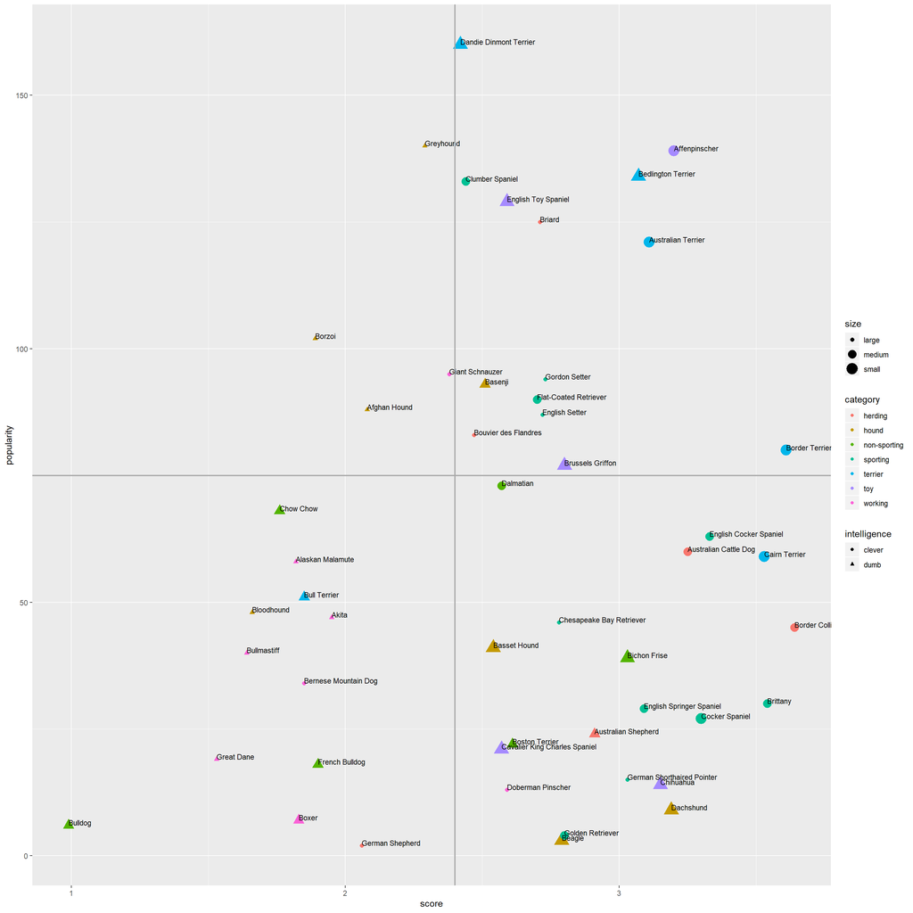

```r
#Below code is to convert values of 'intelligence' column to 'clever' and 'dumb' in line with the values shown in the 'Top Dogs' figure provided in the question

total$intelligence %<>%
  str_replace(pattern = "Brightest", replace = "clever", .) %>%
  str_replace(pattern = "Above average", replace = "clever", .) %>%
  str_replace(pattern = "Excellent", replace = "clever", .) %>%
  str_replace(pattern = "Average", replace = "dumb", .) %>%
  str_replace(pattern = "Fair", replace = "dumb", .) %>%
  str_replace(pattern = "Lowest", replace = "dumb", .)


# change popularity from string into numeric values
total$popularity <- as.numeric(total$popularity)
total$score <- as.numeric(total$score)


# create a ggplot/ggimage object

p <- ggplot(total, aes(score, popularity, shape = intelligence, color = category, size = size))+
   geom_point() +  geom_text(aes(label=breed),colour="black", hjust=0, vjust=0, size=3) +
   geom_hline(yintercept=75, color = "darkgrey", size=0.75)+
   geom_vline(xintercept=2.4, color = "darkgrey", size=0.75)+
  theme(plot.title = element_text(size=20, face="bold",
    margin = margin(0, 0, 0, 0)))

p
```